# Survival Analysis - Melek Series DSI

Markdown ini berisi tutorial analsis survival dengan menggunakan R. Adapun package yang dibutuhkan

- survival
- survminer
- concordance

```r
install.packages(c("survival",
                   "survminer",
                   "concordance"))
```

```r
library(survival)
library(survminer)
library(concordance)

options(scipen=999)
```

Pada library di atas terdapat salah satu contoh dataset yang dapat kita gunakan sebagai latihan pada hari ini. Dataset yang kita gunakan adalah *lung* dataset. Dataset ini merupakan data terkait kondisi kanker dimana deskripsi untuk masing-masing kolom pada dataset ini sebagai berikut

- inst: Institution code
- time: Survival time in days
- status: censoring status 1=censored, 2=dead
- age: Age in years
- sex: Male=1 Female=2
- ph.ecog: ECOG performance score (0=good 5=dead)
- ph.karno: Karnofsky performance score (bad=0-good=100) rated by physician
- pat.karno: Karnofsky performance score as rated by patient
- meal.cal: Calories consumed at meals
- wt.loss: Weight loss in last six months

```r
data("lung")
head(lung)
```

|  | inst | time | status | age | sex | ph.ecog | ph.karno | pat.karno | meal.cal | wt.loss |
| --- | --- | --- | --- | --- | --- | --- | --- | --- | --- | --- |
| 1 | 3 | 306 | 2 | 74 | 1 | 1 | 90 | 100 | 1175 | NA |
| 2 | 3 | 455 | 2 | 68 | 1 | 0 | 90 | 90 | 1225 | 15 |
| 3 | 3 | 1010 | 1 | 56 | 1 | 0 | 90 | 90 | NA | 15 |
| 4 | 5 | 210 | 2 | 57 | 1 | 1 | 90 | 60 | 1150 | 11 |
| 5 | 1 | 883 | 2 | 60 | 1 | 0 | 100 | 90 | NA | 0 |
| 6 | 12 | 1022 | 1 | 74 | 1 | 1 | 50 | 80 | 513 | 0 |

Membuat Kurva Kaplan Meier

```r
fit <- survfit(Surv(time, status)~1, data = lung)
surv_table <- data.frame(time=fit$time,
                         n_risk=fit$n.risk,
                         n_event=fit$n.event,
                         n_censor=fit$n.censor,
                         sur_prob=fit$surv)
surv_table
```

| time | n_risk | n_event | n_censor | sur_prob |
| --- | --- | --- | --- | --- |
| 5 | 228 | 1 | 0 | 0.99561404 |
| 11 | 227 | 3 | 0 | 0.98245614 |
| 12 | 224 | 1 | 0 | 0.97807018 |
| 13 | 223 | 2 | 0 | 0.96929825 |
| 15 | 221 | 1 | 0 | 0.96491228 |
| 26 | 220 | 1 | 0 | 0.96052632 |
| 30 | 219 | 1 | 0 | 0.95614035 |
| 31 | 218 | 1 | 0 | 0.95175439 |
| 53 | 217 | 2 | 0 | 0.94298246 |
| 54 | 215 | 1 | 0 | 0.93859649 |

[output cut: 176 more lines]

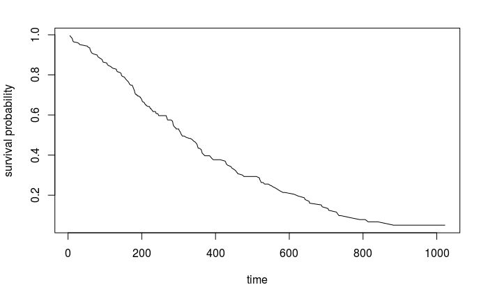

```r
plot(x=surv_table$time,
     y=surv_table$sur_prob,
     type="l",
     ylab="survival probability",
     xlab="time")
```

[figure not shown]

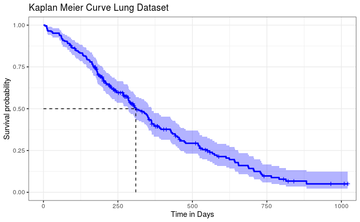

```r
ggsurvplot(fit,
           surv.median.line = "hv",
           ggtheme = theme_bw(),
           color="blue",
           legend="none",
           xlab = "Time in Days") +
           ggtitle("Kaplan Meier Curve Lung Dataset")
```

Membandingkan Kurva Kaplan Meier pada Variabel Sex

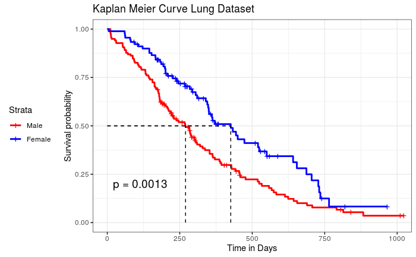

Karena pvalue < alpha (0.05) maka terdapat perbedaan yang signifikan antara kurva survival pasien dengan jenis kelamin laki-laki dan perempuan.

```r
lung$sex <- as.factor(lung$sex)
model_coxph <- coxph (Surv(time, status) ~ sex + age + ph.ecog + ph.karno + pat.karno +
                        meal.cal +wt.loss,data=lung)
model_coxph
```

```
Call:
coxph(formula = Surv(time, status) ~ sex + age + ph.ecog + ph.karno +
    pat.karno + meal.cal + wt.loss, data = lung)

                 coef   exp(coef)    se(coef)      z       p
sex2      -0.55085215  0.57645837  0.20083300 -2.743 0.00609
age        0.01064919  1.01070610  0.01161113  0.917 0.35906
ph.ecog    0.73417669  2.08376570  0.22327093  3.288 0.00101
ph.karno   0.02245506  1.02270908  0.01123989  1.998 0.04574
pat.karno -0.01241655  0.98766022  0.00805416 -1.542 0.12316
meal.cal   0.00003329  1.00003329  0.00025947  0.128 0.89791
wt.loss   -0.01433061  0.98577158  0.00777133 -1.844 0.06518

Likelihood ratio test=28.33  on 7 df, p=0.0001918
n= 168, number of events= 121
   (60 observations deleted due to missingness)
```

```r
options(scipen=999)
summary(model_coxph)
```

```
Call:
coxph(formula = Surv(time, status) ~ sex + age + ph.ecog + ph.karno +
    pat.karno + meal.cal + wt.loss, data = lung)

  n= 168, number of events= 121
   (60 observations deleted due to missingness)

                 coef   exp(coef)    se(coef)      z Pr(>|z|)
sex2      -0.55085215  0.57645837  0.20083300 -2.743  0.00609 **
age        0.01064919  1.01070610  0.01161113  0.917  0.35906
ph.ecog    0.73417669  2.08376570  0.22327093  3.288  0.00101 **
ph.karno   0.02245506  1.02270908  0.01123989  1.998  0.04574 *
pat.karno -0.01241655  0.98766022  0.00805416 -1.542  0.12316
meal.cal   0.00003329  1.00003329  0.00025947  0.128  0.89791
wt.loss   -0.01433061  0.98577158  0.00777133 -1.844  0.06518 .
---
Signif. codes:  0 ‘***’ 0.001 ‘**’ 0.01 ‘*’ 0.05 ‘.’ 0.1 ‘ ’ 1

          exp(coef) exp(-coef) lower .95 upper .95
sex2         0.5765     1.7347    0.3889    0.8545
age          1.0107     0.9894    0.9880    1.0340
ph.ecog      2.0838     0.4799    1.3452    3.2277
ph.karno     1.0227     0.9778    1.0004    1.0455
pat.karno    0.9877     1.0125    0.9722    1.0034
meal.cal     1.0000     1.0000    0.9995    1.0005
wt.loss      0.9858     1.0144    0.9709    1.0009

Concordance= 0.651  (se = 0.029 )
Likelihood ratio test= 28.33  on 7 df,   p=0.0002
Wald test            = 27.58  on 7 df,   p=0.0003
Score (logrank) test = 28.41  on 7 df,   p=0.0002
```

```r
exp_model <- survreg(Surv(time, status) ~ sex + age + ph.ecog + ph.karno + pat.karno +
                        meal.cal +wt.loss, data=lung, dist="exponential")
summary(exp_model)
```

```
Call:
survreg(formula = Surv(time, status) ~ sex + age + ph.ecog +
    ph.karno + pat.karno + meal.cal + wt.loss, data = lung, dist = "exponential")
                  Value  Std. Error     z          p
(Intercept)  7.52683782  1.52796928  4.93 0.00000084
sex2         0.50031618  0.20129933  2.49     0.0129
age         -0.00845108  0.01134190 -0.75     0.4562
ph.ecog     -0.59455748  0.21938715 -2.71     0.0067
ph.karno    -0.01687662  0.01133350 -1.49     0.1365
pat.karno    0.00919070  0.00770107  1.19     0.2327
meal.cal     0.00000981  0.00024874  0.04     0.9685
wt.loss      0.01013615  0.00739891  1.37     0.1707

Scale fixed at 1

Exponential distribution
Loglik(model)= -844   Loglik(intercept only)= -854.9
    Chisq= 21.73 on 7 degrees of freedom, p= 0.0028
Number of Newton-Raphson Iterations: 4
n=168 (60 observations deleted due to missingness)
```

```r
concordance(exp_model)
```

```
Call:
concordance.survreg(object = exp_model)

n= 168
Concordance= 0.6534 se= 0.0291
concordant discordant     tied.x     tied.y    tied.xy
      6992       3709          0         11          0
```

```r
concordance(model_coxph)
```

```
Call:
concordance.coxph(object = model_coxph)

n= 168
Concordance= 0.6512 se= 0.02881
concordant discordant     tied.x     tied.y    tied.xy
      6968       3733          0         11          0
```